# Алгоритмы кластеризации

### Выполнил: Евтеев И. 18БИ-1

Основная задача этого задания - реализация одного из алгоритмов кластеризации. Кроме того, необходимо будет проверить корректность работы алгоритма на тестовых данных, проверить работу алгоритма на данных различной природы, подбирать параметры алгоритма.

```python
import random
import pandas as pd
import pylab as pl
import numpy as np
import scipy.spatial as ss
import sklearn.cluster as sc
import sklearn.manifold as sm
import sklearn.datasets as ds
import sklearn.metrics as smt

import matplotlib.pyplot as plt

%matplotlib inline

plt.rcParams['figure.figsize'] = (12, 8)
```

## Реализация алгоритма

Необходимо выбрать и реализовать самостоятельно один из следующих алгоритмов кластеризации:

- Агломеративная иерархическая кластеризация с поддержкой single-linkage, complete-linkage, average-linkage (параметры - k, linkage)
- DBSCAN. (параметры - epsilon, min_pts) - нужно самостоятельно разобрать и применить критерий качества для DBSCAN
- OPTICS(*). (параметры - epsilon, min_pts)
- Gaussian Mixture Model(**) с использованием maximum a-posteriori для выбора кластера (параметр - k)

(*) - Разберем на занятии 23 марта

(**) - EM кластеризация. Алгоритм сложнее остальных, выбирайте его если уверены в своих навыках программирования.

## Интерфейс

Алгоритм кластеризации должен удовлетворять следующему интерфейсу. Конструктор принимает набор параметров, необходимых для работы алгоритма кластеризации. Метод `fit` подсчитывает параметры модели и возвращает `self`. Метод `predict` возвращает вектор с индексами кластеров для поданных в него объектов `x`

```python
from sklearn.base import BaseEstimator, ClusterMixin
from sklearn.neighbors import NearestNeighbors

from sklearn.cluster._dbscan_inner import dbscan_inner

class DBSCAN(BaseEstimator, ClusterMixin):

    def __init__(self, eps=0.5, min_samples=5):
        self.eps = eps
        self.min_samples = min_samples

    def fit(self, X):
        n_model = NearestNeighbors(
            radius=self.eps, algorithm='auto',
            leaf_size=30, metric='euclidean')
        n_model.fit(X)  # реализация с помощью метода ближайших соседей
        neighborhoods = n_model.radius_neighbors(X,
                                                return_distance=False)  # индексы соседей

        n_neighbors = np.array([len(neighbors)
                                    for neighbors in neighborhoods])  # кол-во соседей у каждого из объекта из выборки

        res = np.full(X.shape[0], -1, dtype=np.intp)  # заполняет массив -1 (пока что все выбросы)

        core_samples = np.asarray(n_neighbors >= self.min_samples,
                                  dtype=np.uint8)  # заполняет 1, если в радиусе >= указанного кол-ва соседей (min_samples)

        dbscan_inner(core_samples, neighborhoods, res)  # вспомогательная ф-ия (раскидывает коры по группам в зависимости от
                                                        # разделения n_model.radius_neighbors; там, где число соседей < min_samples
                                                        # и не содержит центральных, оставляет -1)

        self.res_ = res
        return self

    def predict(self):
        return self.res_

    def fit_predict(self, x):
        self.fit(x)
        return self.res_
```

Сначала проверим реализованный алгоритм кластеризации на классическом наборе данных [Iris](http://www.wikiwand.com/en/Iris_flower_data_set). Загрузим данные (они включены в библиотеку sklearn) и посмотрим на то, как они выглядят в двух проекциях (для простоты используем 2 класса из 3).

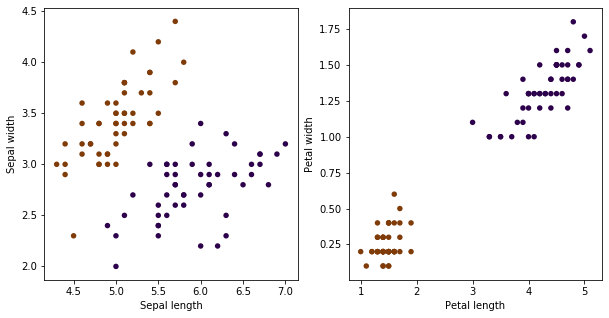

```python
iris = ds.load_iris()
x_iris = iris.data[:100]
y_iris = iris.target[:100]

dbscan = DBSCAN(eps=0.65, min_samples=3).fit(x_iris)
labels = dbscan.predict()

pl.figure(figsize=(10, 5))

pl.subplot(1, 2, 1)
pl.scatter(x_iris[:, 0], x_iris[:, 1], c=labels, cmap=pl.cm.PuOr, lw=0, s=30)
plt.xlabel('Sepal length')
plt.ylabel('Sepal width')

pl.subplot(1, 2, 2)
pl.scatter(x_iris[:, 2], x_iris[:, 3], c=labels, cmap=pl.cm.PuOr, lw=0, s=30)
plt.xlabel('Petal length')
plt.ylabel('Petal width')
pl.show()
```

Видно, что классы разделяются, поэтому можно надеяться, что наш алгоритм "найдет" кластеры, соответствующие исходным классам. Сравним результат работы реализованного алгоритма кластеризации с эталонной кластеризацией, воспользоваавшись метрикой [adjusted rand score](http://scikit-learn.org/stable/modules/generated/sklearn.metrics.adjusted_rand_score.html).

```python
pred_iris = DBSCAN(eps=0.65, min_samples=3).fit_predict(x_iris)
print("Adjusted Rand index for iris is: %.2f" % smt.adjusted_rand_score(y_iris, pred_iris))
```

```
Adjusted Rand index for iris is: 1.00
```

Критерий локтя:

- Инерция (сумма квадратов расстояний от каждой из точек до ближайшего к этой точке центроида)
- Средний диаметр (максимальное расстояние между точками в кластере) или радиус (расстояние от центроида до самой дальней от него точки в кластере)
- Sihouette

Для DBSCAN применяется эвристика по подсчету среднего расстояния до min-pts точек, их сортировки, далее применяется критерий локтя (описание https://habrahabr.ru/post/322034/ или http://www.aaai.org/Papers/KDD/1996/KDD96-037.pdf)

Применим критерий для выбора параметров алгоритма. Измените следующий код таким образом, чтобы кластеризация вызывалась с верным набором параметров, а так же при необходимости изменить этот код (для DBSCAN). На графике можно будет увидеть зависимость критерия от параметров алгоритма. Необходимо выбрать оптимальные значения этих параметров. Возможно, необходимо построить такую визуализацию несколько раз.

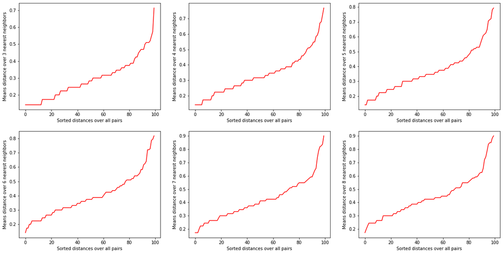

```python
pl.figure(figsize=(20, 10))
for i, n in enumerate(range(3, 9)):
    model = NearestNeighbors(n_neighbors=n, algorithm="ball_tree")
    model.fit(x_iris)
    dist, _ = model.kneighbors(x_iris, n_neighbors=n, return_distance=True)
    dist = dist[:, -1]
    dist = np.sort(dist)

    pl.subplot(2, 3, i+1)
    plt.ylabel('Means distance over {} nearest neighbors'.format(n))
    plt.xlabel('Sorted distances over all pairs')
    pl.plot(dist, c='r')
```

### Вывод:

##### Исходя из полученных результатов примененной эвристики и критерия локтя, можно сделать вывод, что подходящими параметрами будут являтся eps=0.65, min_samples=3, в качестве подтверждения суждения можно привести результаты adjusted rand score, который при этих параметрах принимает значение 1.

Теперь кластеризуйте с помощью реализованного алгоритма данные из лекции.

```
My realization takes 0.02223491668701172 sec
```

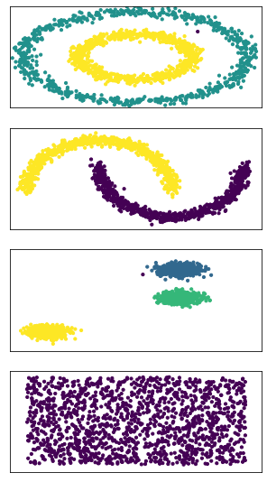

```python
# http://scikit-learn.org/stable/auto_examples/cluster/plot_cluster_comparison.html
%matplotlib inline

import numpy as np
import matplotlib.pyplot as plt
import time

from sklearn import datasets
from sklearn.preprocessing import StandardScaler

np.random.seed(0)

n_samples = 1500
noisy_circles = datasets.make_circles(n_samples=n_samples, factor=.5,
                                      noise=.05)
noisy_moons = datasets.make_moons(n_samples=n_samples, noise=.05)
blobs = datasets.make_blobs(n_samples=n_samples, random_state=8)
no_structure = np.random.rand(n_samples, 2), None

plt.figure(figsize=(2 + 3, 9.5))

data = [noisy_circles, noisy_moons, blobs, no_structure]
start_time = time.time()
for i_dataset, dataset in enumerate(data):
    X, y = dataset
    # normalize dataset for easier parameter selection
    X = StandardScaler().fit_transform(X)

    start_time = time.time()
    dbscan = DBSCAN(eps=0.2, min_samples=3).fit(X)
    labels = dbscan.predict()

    # plot
    plt.subplot(4, 1, i_dataset + 1)
    plt.scatter(X[:, 0], X[:, 1], c=labels, s=10)
    plt.xlim(-2, 2)
    plt.ylim(-2, 2)
    plt.xticks(())
    plt.yticks(())
print('My realization takes %s sec' % (time.time() - start_time))

plt.show()
```

```python
Примените такой же алгоритм реализованный в библиотеке sklearn на тех же данных.
Сравните результат и время, за которое отрабатывает ваш алгоритм и алгоритм из sklearn.
```

```
Sklearn realization takes 0.11345505714416504 sec
```

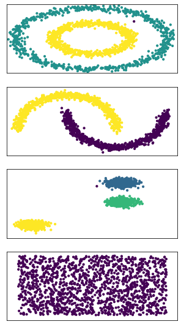

```python
from sklearn.cluster import DBSCAN as DBS

plt.figure(figsize=(2 + 3, 9.5))
start_time = time.time()
for i_dataset, dataset in enumerate(data):
    X, y = dataset
    # normalize dataset for easier parameter selection
    X = StandardScaler().fit_transform(X)

    dbscan = DBS(eps=0.2, min_samples=3).fit(X)
    labels = dbscan.labels_

    # plot
    plt.subplot(4, 1, i_dataset + 1)
    plt.scatter(X[:, 0], X[:, 1], c=labels, s=10)
    plt.xlim(-2, 2)
    plt.ylim(-2, 2)
    plt.xticks(())
    plt.yticks(())
print('Sklearn realization takes %s sec' % (time.time() - start_time))

plt.show()
```